# STAT 432 Final Project

## Logistic Regression with ridge penalty and corss validation.

The above model is obviously not correct. Thus, we decided to use penalized regression and cross validation. Thus, we are going to perform a logistic model with ridge penalty and 10-fold cross validation. Since, the Logistic Regresion Model will not return value with 0 and 1 Thus, we decided to choose the cut-off value based on the distribution of the predict result. Thus, we plot the histogram of the prediction result.

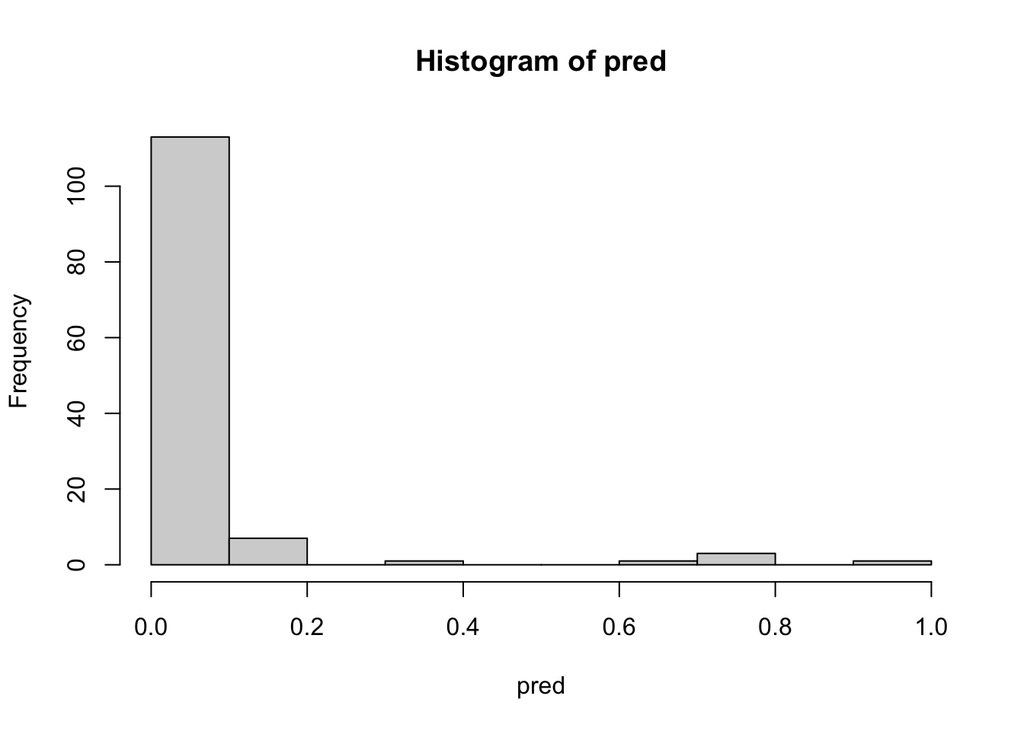

Based on the graph shows above, we decided to choose cut-off value as 0.5. The the prediction result will give 121 FALSE and 5 TRUE.

```
##
## FALSE  TRUE
##   121     5
```

Then, we are going to plot the ROC and calculate AUC.

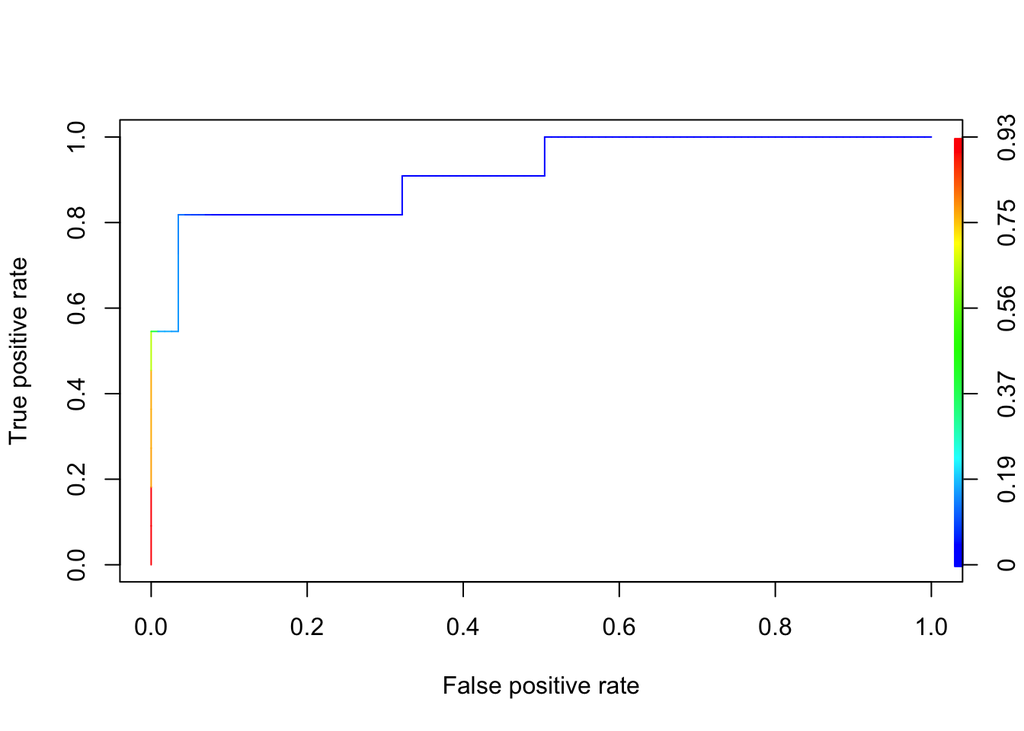

```
## AUC = 0.915415
```

```
##        ytest
##           0   1
##   FALSE 115   6
##   TRUE    0   5
```

Based on the ROC and output given above, AUC is 0.915415, which is a good result

## kmean clustering

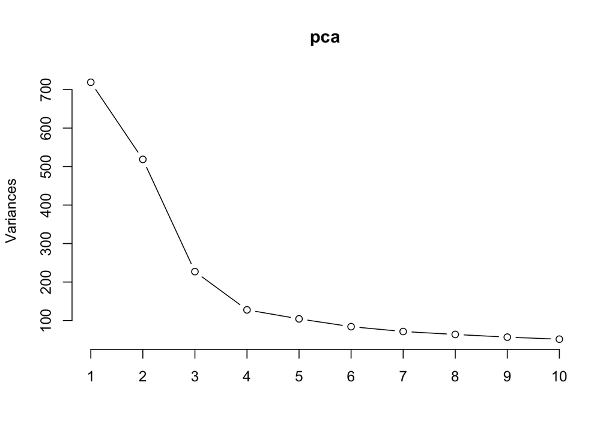

```r
# sub4 = sub3[,-1099]
# kmeanfit <- kmeans(sub4, 2)
# table((kmeanfit$cluster - 1),sub3$y)
pca <- prcomp(sub3[, -ncol(sub3)])

plot(pca, type = "l")
```

```r
comp = pca$x[,1:4]
kfit = kmeans(comp,2)
clusters = kfit$cluster - 1
table(clusters,sub3$y)
```

```
##
## clusters   0   1
##        0 160   9
##        1 297  41
```

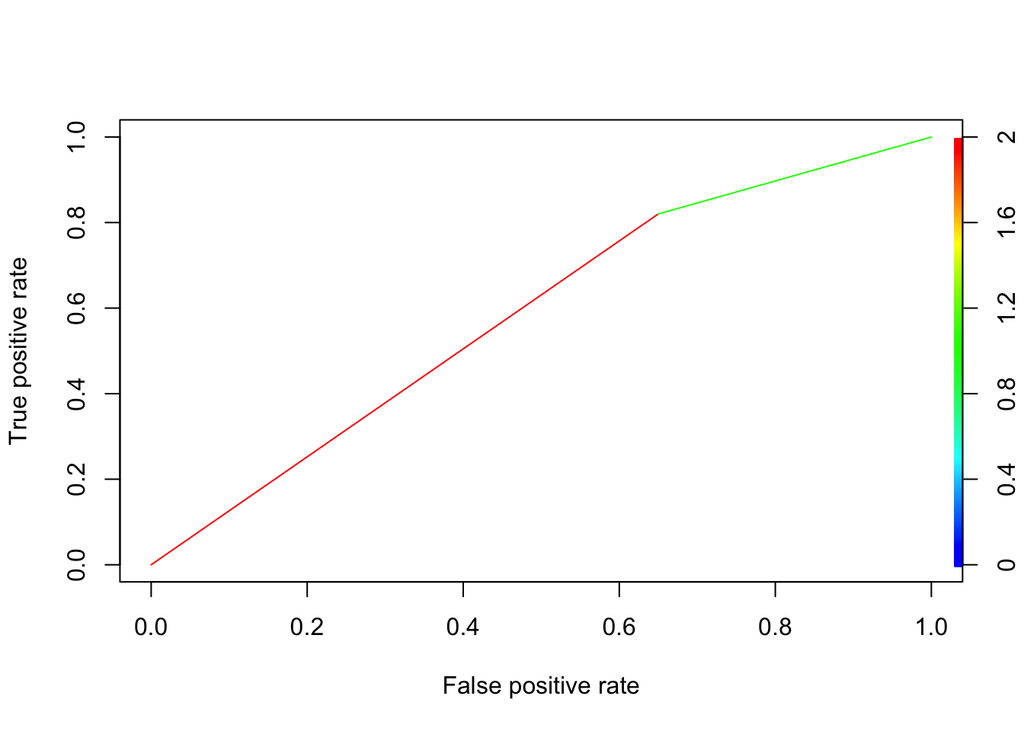

```r
roc2 <- prediction(clusters, sub3$y)
# calculates the ROC curve
perf2 <- performance(roc2,"tpr","fpr")
plot(perf2,colorize=TRUE)
```

```r
performance(roc2, measure = "auc")@y.values[[1]]
```

```
## [1] 0.5850547
```

## tunning tree

```r
library(rpart)
fit = rpart(as.factor(y)~., data= train,control = rpart.control(xval = 10))
fit$cptable
```

```
##     CP nsplit rel error xerror      xstd
## 1 0.44      0      1.00   1.00 0.1342669
## 2 0.08      1      0.56   0.74 0.1171321
## 3 0.06      3      0.40   0.72 0.1156612
## 4 0.01      4      0.34   0.72 0.1156612
```

```r
# prunedtree = prune(fit, cp=cptarg)
# rpart.plot(prunedtree)
# table(,ytest)
pred = predict(fit,Xtest)
result = ifelse(pred[,1] > pred[,2], 0, 1)
table(result,ytest)
```

```
##       ytest
## result   0   1
##      0 115   4
##      1   0   7
```

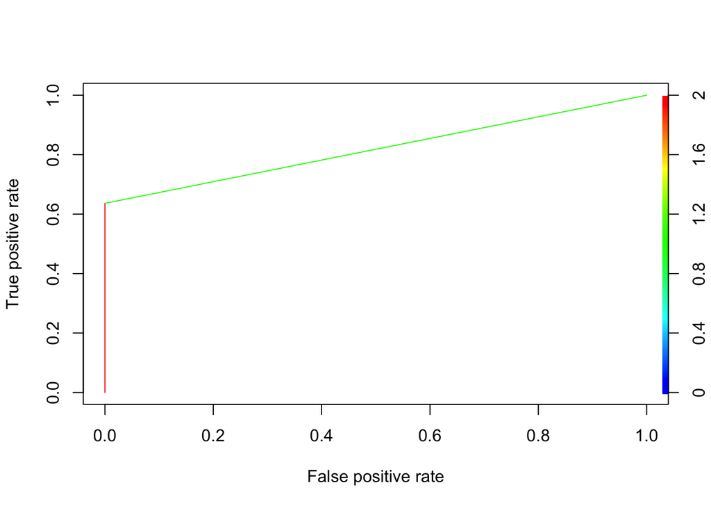

```r
roc2 <- prediction(result, ytest)
# calculates the ROC curve
perf2 <- performance(roc2,"tpr","fpr")
plot(perf2,colorize=TRUE)
```

```r
performance(roc2, measure = "auc")@y.values[[1]]
```

```
## [1] 0.8181818
```